# Détecteur de Spam AT&T

### Contrôle du surapprentissage (entraînement vs test)

Pour confirmer que les deux modèles généralisent bien, on compare le F1-Score obtenu sur les données d'entraînement et sur les données de test. Un écart faible traduit une bonne généralisation ; un F1-Score d'entraînement nettement supérieur au F1-Score de test révélerait du surapprentissage.

```python
# Contrôle du surapprentissage : comparaison F1 entraînement vs F1 test.
# On réutilise les prédictions de test déjà calculées (y_pred1, y_pred2)
# et on calcule en plus le F1-Score sur le jeu d'entraînement pour chaque modèle.
# Un écart faible entre les deux confirme l'absence de surapprentissage.

# --- Modèle 1 : prédictions sur l'entraînement ---
y_train_proba1 = modele1.predict(X_train_pad, verbose=0).flatten()
y_train_pred1  = (y_train_proba1 >= 0.5).astype(int)
f1_train_1 = f1_score(y_train, y_train_pred1)

# --- Modèle 2 : prédictions sur l'entraînement (avec le seuil optimal) ---
y_train_proba2 = modele2.predict([train_ids, train_masks], verbose=0).flatten()
y_train_pred2  = (y_train_proba2 >= seuil_optimal).astype(int)
f1_train_2 = f1_score(y_train, y_train_pred2)

# --- Tableau de contrôle ---
controle = pd.DataFrame({
    'Modèle'          : ['Modèle 1 - Embedding + BiLSTM',
                         f'Modèle 2 - DistilBERT (seuil={seuil_optimal:.2f})'],
    'F1 entraînement' : [round(f1_train_1, 4), round(f1_train_2, 4)],
    'F1 test'         : [round(f1_1, 4),       round(f1_2, 4)]
})
controle['Écart'] = (controle['F1 entraînement'] - controle['F1 test']).round(4)

print('=' * 60)
print('Contrôle du surapprentissage (F1-Score)')
print('=' * 60)
print(controle.to_string(index=False))
print()
print("Lecture : un écart faible entre entraînement et test traduit une bonne")
print("généralisation. Un F1 d'entraînement très supérieur au F1 de test")
print("signalerait un surapprentissage.")
```

[output not shown]

## 7. Comparaison des performances et conclusion

```python
# Tableau récapitulatif des performances des deux modèles.
# Ce tableau constitue le livrable de performance demandé dans l'énoncé.
# Le seuil optimal retenu pour DistilBERT est indiqué pour la transparence.

resultats = pd.DataFrame({
    'Modèle'   : ['Modèle 1 - Embedding + BiLSTM',
                  f'Modèle 2 - DistilBERT (seuil={seuil_optimal:.2f})'],
    'Accuracy' : [round(acc1, 4), round(acc2, 4)],
    'F1-Score' : [round(f1_1, 4), round(f1_2, 4)],
    'AUC-ROC'  : [round(roc1, 4), round(roc2, 4)]
}).set_index('Modèle')

print('=' * 68)
print('Tableau comparatif des performances sur le jeu de test')
print('=' * 68)
print(resultats.to_string())
```

```
====================================================================
Tableau comparatif des performances sur le jeu de test
====================================================================
                                    Accuracy  F1-Score  AUC-ROC
Modèle
Modèle 1 - Embedding + BiLSTM         0.9836    0.9333   0.9840
Modèle 2 - DistilBERT (seuil=0.60)    0.9826    0.9291   0.9937
```

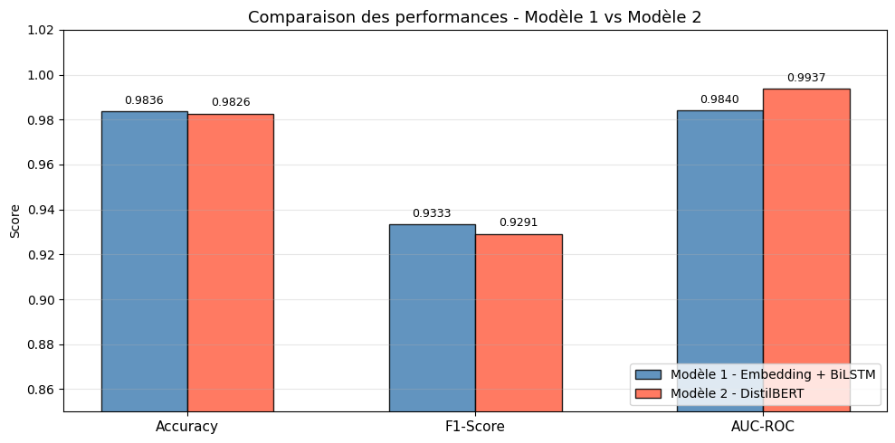

```python
# Visualisation comparative des métriques des deux modèles.
# L'axe vertical commence à 0.85 pour mieux visualiser les différences entre modèles.

fig, ax = plt.subplots(figsize=(10, 5))

metriques = ['Accuracy', 'F1-Score', 'AUC-ROC']
x         = np.arange(len(metriques))
largeur   = 0.3
vals_m1   = [acc1, f1_1, roc1]
vals_m2   = [acc2, f1_2, roc2]

barres1 = ax.bar(x - largeur / 2, vals_m1, largeur,
                 label='Modèle 1 - Embedding + BiLSTM',
                 color='steelblue', edgecolor='black', alpha=0.85)
barres2 = ax.bar(x + largeur / 2, vals_m2, largeur,
                 label='Modèle 2 - DistilBERT',
                 color='tomato', edgecolor='black', alpha=0.85)

# Annotation des valeurs au-dessus de chaque barre
for barre in list(barres1) + list(barres2):
    ax.annotate(
        f'{barre.get_height():.4f}',
        xy=(barre.get_x() + barre.get_width() / 2, barre.get_height()),
        xytext=(0, 4), textcoords='offset points',
        ha='center', va='bottom', fontsize=9
    )

ax.set_xticks(x)
ax.set_xticklabels(metriques, fontsize=11)
ax.set_ylim(0.85, 1.02)
ax.set_ylabel('Score')
ax.set_title('Comparaison des performances - Modèle 1 vs Modèle 2', fontsize=13)
ax.legend(loc='lower right')
ax.grid(axis='y', alpha=0.3)

plt.tight_layout()
plt.show()
```

## Conclusion

### Résumé de la démarche

Nous avons construit et comparé deux modèles de deep learning pour détecter automatiquement les SMS indésirables sur le jeu de données spam.csv (5 572 messages, 13 % de spam), en suivant les deux recommandations de l'énoncé.

**Modèle 1 - Embedding + BiLSTM** : architecture légère entraînée entièrement sur nos données. La couche d'Embedding apprend des représentations vectorielles des mots spécifiques au vocabulaire SMS, et le BiLSTM exploite la structure séquentielle dans les deux sens de lecture.

**Modèle 2 - DistilBERT (transfert d'apprentissage)** : modèle pré-entraîné sur des milliards de phrases, auquel une tête de classification a été ajoutée et affinée sur notre corpus. DistilBERT apporte une compréhension profonde du contexte linguistique sans nécessiter de grandes quantités de données d'entraînement.